# Assignment 6

Michael Culshaw-Maurer

2/20/2017

First, some parameters that we’ll use the whole time:

```r
load("/Users/MJ/GitHub/ECL_233/SARS.Rdata")
reps <- 10000
Tf <- 10
q <- 0.4
```

First up is partial absolute control. First, take the number of infected individuals, then determine whether they’re part of your quarantined subset using a coin flip weighted based on q. Then, take the individuals that are NOT in quarantine and have them draw a # of infections from the SARS data, and total this up.

```r
Npa <- matrix(NA,Tf,reps) # make a matrix with Tf and reps
Npa[1,] <- 1 # start with one infected individual in each rep

for(i in 1:reps){
  for(t in 1:(Tf-1)){
    if(Npa[t,i]>0){ # if there is still at least one infected individual
      x <- rbinom(1,size=Npa[t,i],1-q) # flip the coin to determine how many of the current individuals are not in your protected subgroup, define this as x
      Npa[t+1,i]=sum(sample(SARS,size=x,replace=TRUE)) # now sample from those that are NOT in your protected subgroup
      }else{Npa[t+1,i]<-0} # if nobody is infected now, nobody is infected next time
  }
}
```

Next up is homogenous partial control. For this one, first each infected individual draws from the SARS data, making a number of “possible infections”. Then for each possible infection, we flip a coin weighted based on q in order to determine the success of each possible infection (whether the mask worked or not). Then total up the number of successful infections

```r
Nhp <- matrix(NA,Tf,reps) # same thing with the matrix as above
Nhp[1,] <- 1

for(i in 1:reps){
  for(t in 1:(Tf-1)){
    if(Nhp[t,i]>0){
      possible.infections <- sum(sample(SARS,size=Nhp[t,i],replace=TRUE)) # draw from SARS data to get the total possible infections
      Nhp[t+1,i]=rbinom(1,size=possible.infections,prob = 1-q) # flip a coin based on q. The # of times is the number of possible infections
    }else{Nhp[t+1,i]<-0} # same thing as above, no infection now = no infection later
  }
}
```

Plot histograms of both outputs

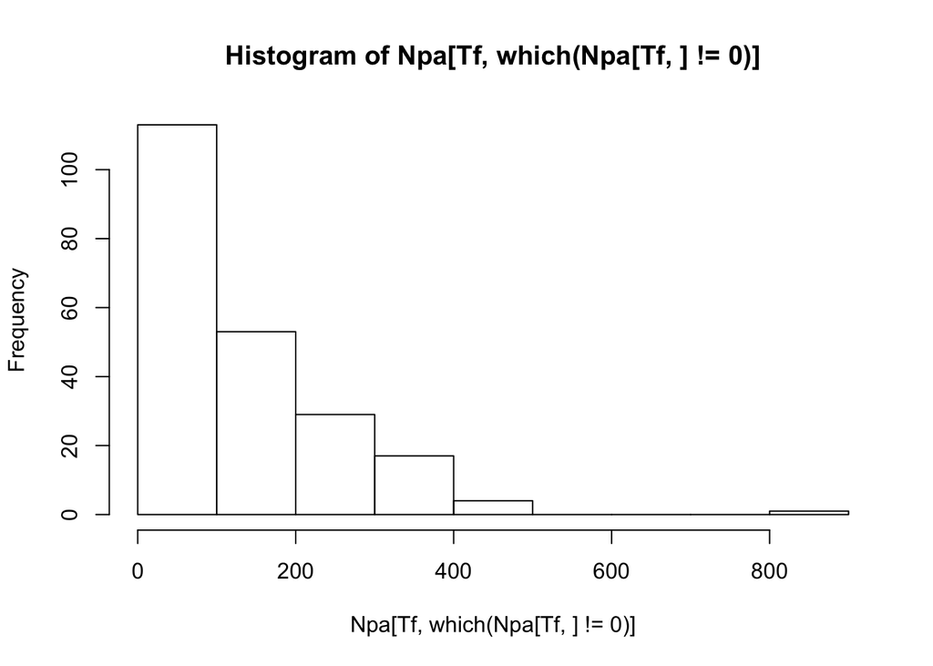

```r
hist(Npa[Tf,which(Npa[Tf,]!=0)])
```

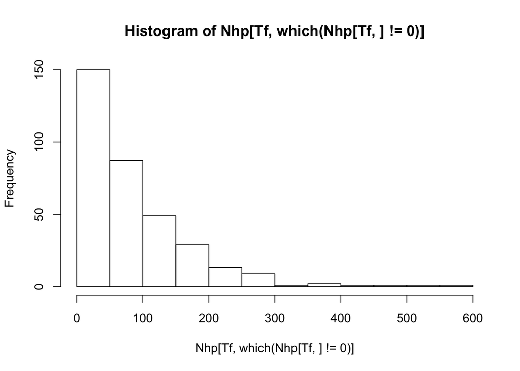

```r
hist(Nhp[Tf,which(Nhp[Tf,]!=0)])
```

Part 2. Now we just loop the two functions through different q values and compute the prob of extinction for each q value and each strategy. First up is homogenous partial control.

```r
q.seq <- seq(from=0,to=1,by=0.01) # create a sequence of q values
Nhp.prob <- numeric(length(q.seq)) # create empty vector of extinction probs

for(j in 1:length(q.seq)){ # do what we did before, but loop through q.seq
for(i in 1:reps){
  for(t in 1:(Tf-1)){
    if(Nhp[t,i]>0){
      possible.infections <- sum(sample(SARS,size=Nhp[t,i],replace=TRUE))
      Nhp[t+1,i]=rbinom(1,size=possible.infections,prob = 1-q.seq[j])
    }else{Nhp[t+1,i]<-0}
  }
}
Nhp.prob[j] <- length(which(Nhp[Tf,]==0))/reps # for each q value, calculate probability of extinction
}
```

Same exact thing with partial absolute control.

```r
Npa.prob <- numeric(length(q.seq))

for(j in 1:length(q.seq)){
for(i in 1:reps){
  for(t in 1:(Tf-1)){
    if(Npa[t,i]>0){
      x <- rbinom(1,size=Npa[t,i],1-q.seq[j]) # flip the coin to determine how many of the current individuals are not in your protected subgroup, define this as x
      Npa[t+1,i]=sum(sample(SARS,size=x,replace=TRUE)) # now sample from those that are NOT in your protected subgroup
    }else{Npa[t+1,i]<-0}
  }
}
  Npa.prob[j] <- length(which(Npa[Tf,]==0))/reps
}
```

Now plot them against each other:

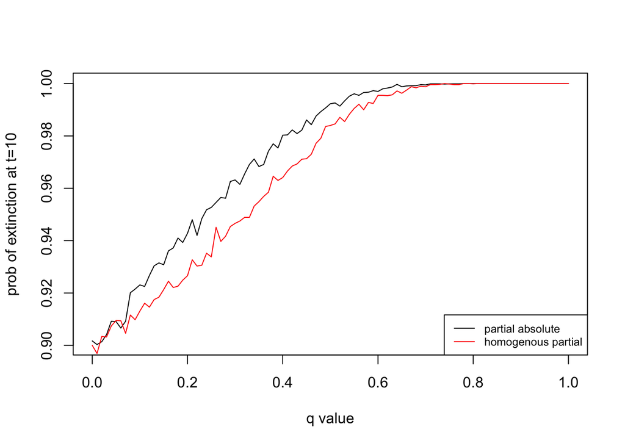

```r
plot(q.seq,Npa.prob,type="l",ylab="prob of extinction at t=10",xlab="q value")
lines(q.seq,Nhp.prob,col="red")
legend("bottomright", col=c("black","red"),
       legend=c("partial absolute","homogenous partial"),lty = rep(1,2),cex=0.75)
```